# Análise das tabelas sku_dataset e 2024.csv

Livia Bonotto e Gabriel Torres

2024-08-09

# Introdução

Esse notebook fará uma primeira análise das tabelas sku_dataset (tabela de produto) e 2024 (tabela de transações). Essas tabelas foram escolhidas com o intuito de entender mais sobre a feature **Recomendações de cross-sell e produtos substitutos** para a criação do artefato da sprint 1.

# Importando bibliotecas

```r
knitr::opts_chunk$set(echo = TRUE)
library(readr)
library(ggplot2)
library(corrplot)
library(dplyr)
library(tidyr)
library(purrr)
library(combinat)
```

# Carregando os dataframes

```r
df_produtos <- read_csv2("sku_dataset.csv")
```

```
## ℹ Using "','" as decimal and "'.'" as grouping mark. Use `read_delim()` for more control.
```

```r
df_vendas <- read_csv("2024.csv")
```

# Visualizando os dataframes

```r
head(df_produtos)
```

```
## # A tibble: 6 × 9
##       cod_prod nome_abrev  nome_completo descricao categoria sub_categoria marca
##          <dbl> <chr>       <chr>         <chr>     <chr>     <chr>         <chr>
## 1 603078352615 Acne Solut… Acne Solutio… Sabonete… Corpo     Sabonete líq… Clin…
## 2 131384024501 Pep Start … Pep Start Da… Protetor… Corpo     Protetor sol… Clin…
## 3  85873708529 Deep Comfo… Deep Comfort… Sabonete… Corpo     Sabonete líq… Clin…
## 4 579926605113 Lipikar Wa… Lipikar Wash… Sabonete… Corpo     Sabonete líq… La R…
## 5 397769055946 Anthelios … Anthelios AO… Protetor… Corpo     Protetor sol… La R…
## 6 981647487600 Basil Whit… Basil & Whit… Sabonete… Corpo     Sabonete líq… Nivea
## # ℹ 2 more variables: conteudo_valor <chr>, conteudo_medida <chr>
```

```r
head(df_vendas)
```

```
## # A tibble: 6 × 7
##   data       cod_vendedor cod_loja       cod_transacao quantidade cod_prod preco
##   <date>            <dbl> <chr>          <chr>              <dbl>    <dbl> <dbl>
## 1 2024-05-31          239 SP Capital Su… 0003c03474             7  7.11e11 370.
## 2 2024-05-30          145 RJ_31          000a0cb29f             5  2.18e11 176.
## 3 2024-05-29          909 SP Capital Le… 000a114a81             4  7.62e11 182.
## 4 2024-05-29          909 SP Capital Le… 000a114a81             8  8.52e11 356.
## 5 2024-05-30          240 SC_30          000a8aa0be             1  1.21e11  29.7
## 6 2024-05-29          697 RS_16          000b7a8be7             2  7.22e11  96.5
```

# Verificação da estrutura de dados

```r
str(df_produtos)
```

```
## spc_tbl_ [563 × 9] (S3: spec_tbl_df/tbl_df/tbl/data.frame)
##  $ cod_prod       : num [1:563] 6.03e+11 1.31e+11 8.59e+10 5.80e+11 3.98e+11 ...
##  $ nome_abrev     : chr [1:563] "Acne Solutions Cleansing Bar" "Pep Start Daily UV" "Deep Comfort Body Wash" "Lipikar Wash Gentle Foaming" ...
##  $ nome_completo  : chr [1:563] "Acne Solutions Cleansing Bar for Face & Body" "Pep Start Daily UV Protector Broad Spectrum SPF 50" "Deep Comfort Body Wash" "Lipikar Wash AP+ Gentle Foaming Moisturizing Wash" ...
##  $ descricao      : chr [1:563] "Sabonete líquido Clinique Acne Solutions Cleansing Bar for Face & Body  para Corpo" "Protetor solar Clinique Pep Start Daily UV Protector Broad Spectrum SPF 50  para Corpo" "Sabonete líquido Clinique Deep Comfort Body Wash  para Corpo" "Sabonete líquido La Roche-P…
##  $ categoria      : chr [1:563] "Corpo" "Corpo" "Corpo" "Corpo" ...
##  $ sub_categoria  : chr [1:563] "Sabonete líquido" "Protetor solar" "Sabonete líquido" "Sabonete líquido" ...
##  $ marca          : chr [1:563] "Clinique" "Clinique" "Clinique" "La Roche-Posay" ...
##  $ conteudo_valor : chr [1:563] "156.0" "30.0" "204.0" "405.0" ...
##  $ conteudo_medida: chr [1:563] "ml" "ml" "ml" "ml" ...
##  - attr(*, "spec")=
##   .. cols(
##   ..   cod_prod = col_double(),
##   ..   nome_abrev = col_character(),
##   ..   nome_completo = col_character(),
##   ..   descricao = col_character(),
##   ..   categoria = col_character(),
##   ..   sub_categoria = col_character(),
##   ..   marca = col_character(),
##   ..   conteudo_valor = col_character(),
##   ..   conteudo_medida = col_character()
##   .. )
##  - attr(*, "problems")=<externalptr>
```

```r
str(df_vendas)
```

```
## spc_tbl_ [790,696 × 7] (S3: spec_tbl_df/tbl_df/tbl/data.frame)
##  $ data         : Date[1:790696], format: "2024-05-31" "2024-05-30" ...
##  $ cod_vendedor : num [1:790696] 239 145 909 909 240 697 697 788 123 123 ...
##  $ cod_loja     : chr [1:790696] "SP Capital Sul_18" "RJ_31" "SP Capital Leste/Oeste_58" "SP Capital Leste/Oeste_58" ...
##  $ cod_transacao: chr [1:790696] "0003c03474" "000a0cb29f" "000a114a81" "000a114a81" ...
##  $ quantidade   : num [1:790696] 7 5 4 8 1 2 1 4 8 7 ...
##  $ cod_prod     : num [1:790696] 7.11e+11 2.18e+11 7.62e+11 8.52e+11 1.21e+11 ...
##  $ preco        : num [1:790696] 370.3 176.3 181.9 356.3 29.7 ...
##  - attr(*, "spec")=
##   .. cols(
##   ..   data = col_date(format = ""),
##   ..   cod_vendedor = col_double(),
##   ..   cod_loja = col_character(),
##   ..   cod_transacao = col_character(),
##   ..   quantidade = col_double(),
##   ..   cod_prod = col_double(),
##   ..   preco = col_double()
##   .. )
##  - attr(*, "problems")=<externalptr>
```

# Resumo estatístico

```r
summary(df_produtos)
```

```
##     cod_prod          nome_abrev        nome_completo       descricao
##  Min.   :6.587e+09   Length:563         Length:563         Length:563
##  1st Qu.:2.506e+11   Class :character   Class :character   Class :character
##  Median :4.800e+11   Mode  :character   Mode  :character   Mode  :character
##  Mean   :5.024e+11
##  3rd Qu.:7.696e+11
##  Max.   :9.970e+11
##   categoria         sub_categoria         marca           conteudo_valor
##  Length:563         Length:563         Length:563         Length:563
##  Class :character   Class :character   Class :character   Class :character
##  Mode  :character   Mode  :character   Mode  :character   Mode  :character
##
##
##
##  conteudo_medida
##  Length:563
##  Class :character
##  Mode  :character
##
##
##
```

```r
summary(df_vendas)
```

```
##       data             cod_vendedor      cod_loja         cod_transacao
##  Min.   :2024-01-30   Min.   :   1.0   Length:790696      Length:790696
##  1st Qu.:2024-02-29   1st Qu.: 246.0   Class :character   Class :character
##  Median :2024-04-29   Median : 488.0   Mode  :character   Mode  :character
##  Mean   :2024-04-14   Mean   : 496.8
##  3rd Qu.:2024-05-30   3rd Qu.: 755.0
##  Max.   :2024-06-13   Max.   :1000.0
##    quantidade       cod_prod             preco
##  Min.   :1.000   Min.   :6.587e+09   Min.   :  11.33
##  1st Qu.:2.000   1st Qu.:2.605e+11   1st Qu.: 104.87
##  Median :4.000   Median :5.539e+11   Median : 207.87
##  Mean   :3.856   Mean   :5.274e+11   Mean   : 358.36
##  3rd Qu.:5.000   3rd Qu.:7.892e+11   3rd Qu.: 384.27
##  Max.   :8.000   Max.   :9.885e+11   Max.   :3976.69
```

# Descrição das variáveis:

- **df_produtos:**
  - `cod_prod`: código único do produto.
  - `nome_abrev`: nome abreviado do produto.
  - `nome_completo`: nome completo do produto.
  - `descricao`: descrição detalhada do produto.
  - `categoria`: categoria principal do produto (ex: Corpo).
  - `sub_categoria`: subcategoria do produto (ex: Sabonete líquido).
  - `marca`: marca do produto.
  - `conteudo_valor`: valor da medida do produto (ex: 1ml, 2L, 3mg).
  - `conteudo_medida`: unidade de medida do conteúdo (ex: ml, L, mg).
- **df_vendas:**
  - `data`: data da transação.
  - `cod_vendedor`: código do vendedor.
  - `cod_loja`: código da loja.
  - `cod_transacao`: código único da transação.
  - `quantidade`: quantidade vendida do produto.
  - `cod_prod`: código do produto vendido.
  - `preco`: preço de venda do produto.

# Análise univariada

## Histograma da quantidade de produtos vendidos pelo valor da transação

Aqui criamos visualizações para explorar as distribuições da variável `preco` e sua frequência no dataframe. Para isto, criamos um `df_agregado` que soma todos os valores de transações que se repetem no dataframe. Após isso, colocamos eles em uma faixa de valor financeiro e verificamos qual é o valor que é feito nas vendas.

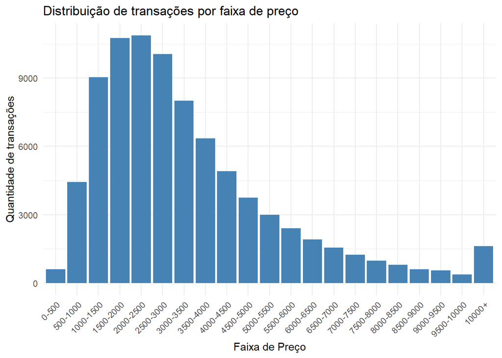

```r
df_agregado <- df_vendas %>%
  group_by(cod_transacao) %>%
  summarise(total_preco = sum(preco, na.rm = TRUE))

max_valor <- max(df_agregado$total_preco, na.rm = TRUE)
intervalo <- 500  # Definindo o intervalo das faixas

max_valor_ajustado <- ceiling(max_valor / intervalo) * intervalo


df_faixa <- df_agregado %>%
  mutate(faixa_preco = case_when(
    total_preco > 10000 ~ "10000+",
    TRUE ~ cut(total_preco,
               breaks = seq(0, max_valor_ajustado, by = intervalo),
               include.lowest = TRUE,
               right = FALSE,
               labels = paste(seq(0, max_valor_ajustado - intervalo, by = intervalo),
                              seq(intervalo, max_valor_ajustado, by = intervalo), sep = "-"))
  ))

#transformar faixa_preco em fator e ordenar níveis
df_faixa <- df_faixa %>%
  mutate(faixa_preco = factor(faixa_preco, levels = c(paste(seq(0, max_valor_ajustado - intervalo, by = intervalo),
                                                            seq(intervalo, max_valor_ajustado, by = intervalo), sep = "-"),
                                                     "10000+")))

#contagem de transações por faixa de preço
contagem_faixa <- df_faixa %>%
  count(faixa_preco)

#criando o gráfico de colunas
ggplot(contagem_faixa, aes(x = faixa_preco, y = n)) +
  geom_col(fill = "steelblue") +
  labs(x = "Faixa de Preço", y = "Quantidade de transações", title = "Distribuição de transações por faixa de preço") +
  theme_minimal() +
  theme(axis.text.x = element_text(angle =45,hjust=1))
```

Com base nisso, é possível perceber que a maioria das transações tem como valor final entre 2000-2500, seguido de 1500-2000. Enquanto isso, os valores mais baixos são os de 0-500 e 9500-10000. Pensando no valor dessas transações, é possível analisar que talvez, a maioria das transações são para revenda (B2B).

```r
media_valor_transacoes <- mean(df_faixa$total_preco, na.rm = TRUE)
print(media_valor_transacoes)
```

```
## [1] 3381.063
```

## Identificando outliers no preço dos produtos

```r
estatisticas <- df_agregado %>%
  summarise(
    Q1 = quantile(total_preco, 0.25, na.rm = TRUE),
    Q3 = quantile(total_preco, 0.75, na.rm = TRUE),
    IQR = IQR(total_preco, na.rm = TRUE)
  )

# colocando limites para identificar outliers
limite_inferior <- estatisticas$Q1 - 1.5 * estatisticas$IQR
limite_superior <- estatisticas$Q3 + 1.5 * estatisticas$IQR

df_outliers <- df_agregado %>%
  mutate(
    outlier = total_preco < limite_inferior | total_preco > limite_superior
  )


outliers_resumo <- df_outliers %>%
  filter(outlier) %>%
  summarise(
    total_outliers = n(),
    valor_minimo_outlier = min(total_preco, na.rm = TRUE),
    valor_maximo_outlier = max(total_preco, na.rm = TRUE)
  )

print(outliers_resumo)
```

```
## # A tibble: 1 × 3
##   total_outliers valor_minimo_outlier valor_maximo_outlier
##            <int>                <dbl>                <dbl>
## 1           4076                7913.               23255.
```

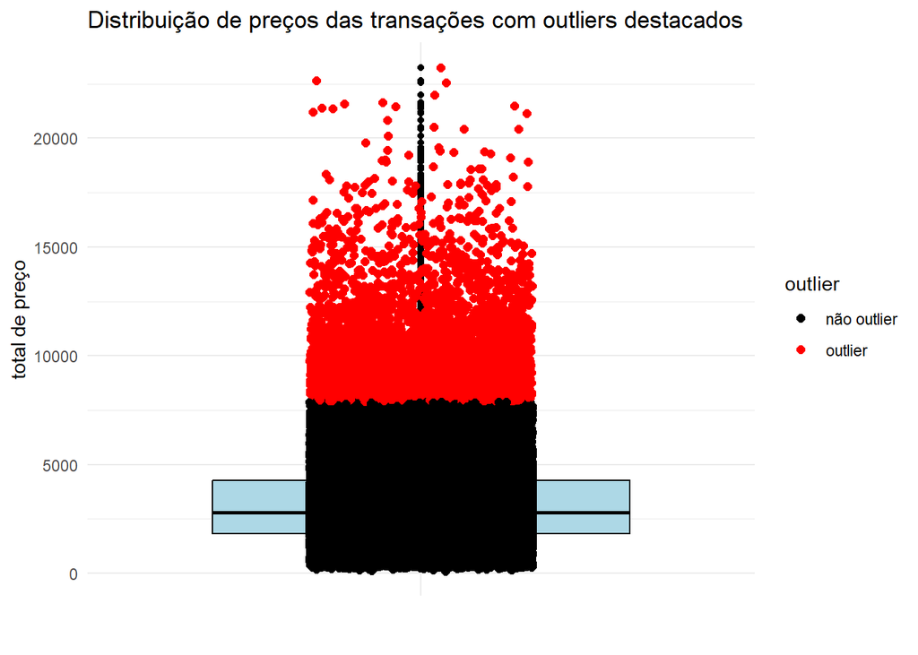

```r
# gráfico para vermos os outliers
ggplot(df_outliers, aes(x = "", y = total_preco)) +
  geom_boxplot(fill = "lightblue", color = "black") +
  geom_jitter(aes(color = outlier), width = 0.2, size = 2) +
  labs(x = "", y = "total de preço", title = "Distribuição de preços das transações com outliers destacados") +
  theme_minimal() +
  scale_color_manual(values = c("black", "red"), labels = c("não outlier", "outlier"))
```

# Análise bivariada

## Gráfico de barras para explorar a relação entre categoria e preço médio

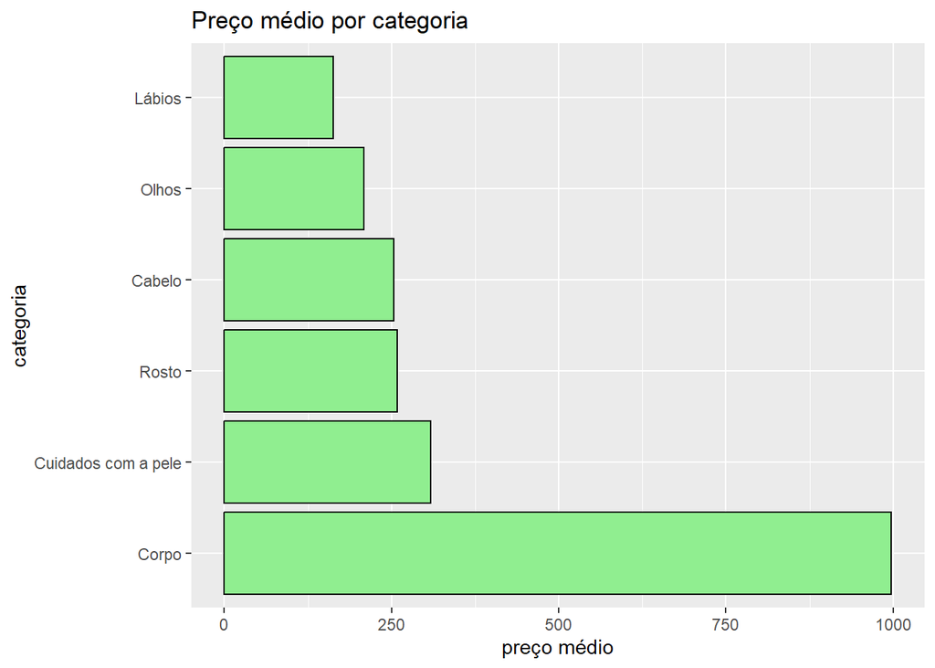

```r
df_prod_vendas <- merge(df_vendas, df_produtos, by = "cod_prod")
df_categoria_preco <- aggregate(preco ~ categoria, data = df_prod_vendas, FUN = mean)
ggplot(df_categoria_preco, aes(x = reorder(categoria, -preco), y = preco)) + geom_bar(stat = "identity", fill = "lightgreen", color = "black") + labs(title = "Preço médio por categoria", x = "categoria", y = "preço médio") + coord_flip()
```

Percebemos que a categoria `corpo` tem disparadamente um preço médio maior que as outras categorias. Essa análise é importante para o futuro do modelo de cross-sell, talvez para evitar viéses, devemos cortar parte das transações que tenham produto de `corpo`, assim, equiparando todas as categorias.

## Análise de correlação

Calculamos a matriz de correlação entre variáveis numéricas no dataframe `df_vendas` e exibimos essa matriz visualmente usando o pacote `corrplot`. A correlação mede a relação linear entre pares de variáveis.

```r
correlation_matrix <- cor(df_vendas[, sapply(df_vendas, is.numeric)])
print(correlation_matrix)
```

```
##               cod_vendedor    quantidade      cod_prod        preco
## cod_vendedor  1.0000000000 -0.0003119173  0.0005168375  0.001900659
## quantidade   -0.0003119173  1.0000000000 -0.0027850263  0.358488399
## cod_prod      0.0005168375 -0.0027850263  1.0000000000 -0.044905020
## preco         0.0019006588  0.3584883991 -0.0449050196  1.000000000
```

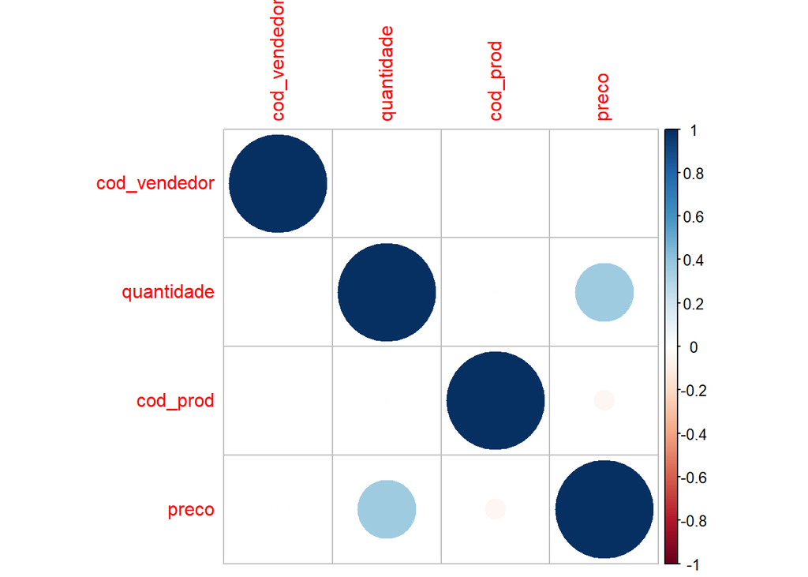

```r
corrplot(correlation_matrix, method = "circle")
```

As colunas de quantidade e preço tem uma certa correlação. O que, em uma primeira análise, faz sentido, visto que, quanto mais produtos comprados, maior será o preço da transação.

# Análise Multivariada

```r
df_vendas_numeric <- df_vendas[, sapply(df_vendas, is.numeric)]

# usando prcomp pro pca
pca_result <- prcomp(df_vendas_numeric, scale. = TRUE)

# visualizando
summary(pca_result)
```

```
## Importance of components:
##                           PC1    PC2    PC3    PC4
## Standard deviation     1.1669 1.0001 0.9995 0.7994
## Proportion of Variance 0.3404 0.2501 0.2498 0.1598
## Cumulative Proportion  0.3404 0.5905 0.8402 1.0000
```

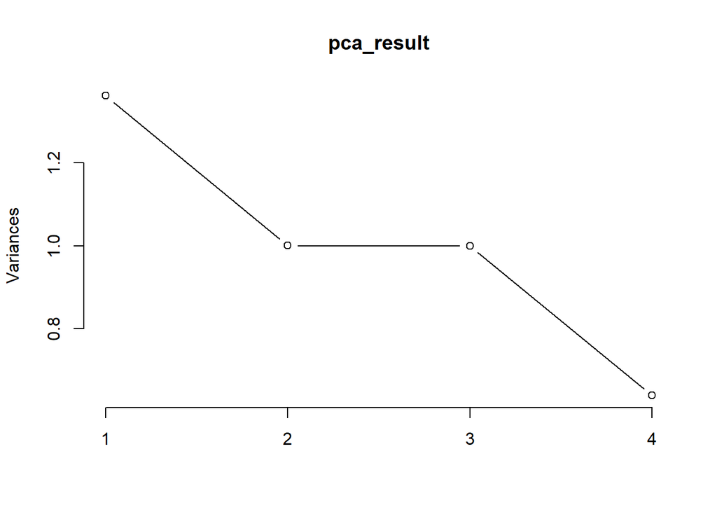

```r
plot(pca_result, type = "l")
```

Como conclusão dos relatórios gerados por esta análise, algumas hipóteses são levantadas:

1. Pode ser possível reduzir a dimensionalidade dos dados, mantendo apenas os componentes principais que explicam a maior parte da variabilidade. Se mantivermos apenas os 3 primeiros PCs, teriamos 84,02% da variabilidade.
2. Mantendo os dois primeiros PCs, conseguiriamos diminuir bastante a dimensionalidade e ainda teríamos cerca de 59% da variabilidade.

# Cross-sell e Produtos substitutos

## Primeira Análise

Em um primeiro momento, decidimos avançar com a proposta da feature de `Cross-sell e produtos substitutos` . Para os produtos substitutos, estamos a estratégia atual foi agrupar categorias e subcategorias, sugerindo os produtos mais vendidos dentro da mesma subcategoria do produto original. Essa estratégia deve mudar para a próxima sprint e o motivo disto, está nas conclusões.

```r
# primeiro, agrupando por código de transação, listamos os produtos comprados juntos (na mesma transação)
produtos_juntos <- df_vendas %>%
  group_by(cod_transacao) %>%
  summarise(cod_prod = list(cod_prod))

# depois criamos uma função para gerar combinações de pares de produtos, limitando o tamanho do vetor (porque quando não limitamos, passa do tamanho máximo. Temos que ver isso para as próximas sprints)
generate_pairs <- function(produtos) {
  if (length(produtos) > 1 && length(produtos) <= 50) {
    return(as.data.frame(t(combn(produtos, 2))))
  } else {
    return(NULL)
  }
}

# procuramos combinacoes de produtos comprados juntos
cross_sell_pairs <- produtos_juntos %>%
  pull(cod_prod) %>%
  map_df(generate_pairs)

# renomeamos as colunas pra prod1 e prod2
names(cross_sell_pairs) <- c("prod1", "prod2")

# contagem das combinações mais frequentes
cross_sell_df <- cross_sell_pairs %>%
  count(prod1, prod2, name = "frequency") %>%
  arrange(desc(frequency))


# para identificar produtos substitutos, faremos um merge para trazer informacoes como categoria e subcategoria dos produtos no dataframe

df_vendas_produtos <- df_vendas %>%
  left_join(df_produtos, by = "cod_prod")

# agrupamos por categoria e subcategoria, e contamos transações onde diferentes produtos apareceram
substitutos_df <- df_vendas_produtos %>%
  group_by(categoria, sub_categoria, cod_transacao) %>%
  summarise(cod_prod = list(cod_prod), .groups = "drop") %>%
  ungroup()

# encontramos combinações de produtos substitutos
substitutos_pairs <- substitutos_df %>%
  pull(cod_prod) %>%
  map_df(generate_pairs)

# renomeamos as colunas dos pares
names(substitutos_pairs) <- c("produto_orig", "substituto")

# contagem das combinações de substitutos mais frequentes
substitutos_df <- substitutos_pairs %>%
  count(produto_orig, substituto, name = "frequency") %>%
  arrange(desc(frequency))
```

```r
# Resultados
print(head(cross_sell_df))
```

```
##          prod1        prod2 frequency
## 1   6587422396 839689622605       360
## 2 120545844331 839689622605       352
## 3 223008708789 839689622605       351
## 4 304995765983 839689622605       350
## 5 839689622605 971586503165       349
## 6 648743525109 839689622605       348
```

```r
print(head(substitutos_df))
```

```
##   produto_orig   substituto frequency
## 1 839689622605 971586503165       349
## 2 648743525109 839689622605       348
## 3 232491230165 839689622605       342
## 4 223008708789 972341323066       341
## 5 714736797348 857199140808       334
## 6 359370058440 753482837724       329
```

# Conclusão

O dataframe de vendas é extremamente volumoso, com um grande número de transações registradas. As transações se repetem ao longo do dataframe por produto, então se uma transação tem mais de um produto, ela aparecerá em mais de uma linha (cada uma referente a um produto comprado). Além disso, nessas transações, é possível analisar o preço delas, mas em df_produto não é possível analisar o preço do produto em si. Ainda falando em preço, as transações atingem a média de 3000, nos fazendo pensar que a maioria dos produtos podem estar sendo vendidos em um modelo B2B. Também não há informações sobre a moeda utilizada.

Em relação ao tamanho do dataframe de vendas, observamos que a aplicação da Análise de Componentes Principais (PCA) indica que poderíamos reduzir significativamente a dimensionalidade dos dados. Mantendo apenas os dois primeiros componentes, conseguiríamos manter 59% da variabilidade dos dados, o que pode ser suficiente para muitas análises, ao mesmo tempo em que reduzimos o volume de dados. No entanto, é necessário avaliar se seguir por esse caminho não significaria perder dados relevantes para as análises.

Sobre o dataframe de produto, ele especifica mais sobre o que é aquele produto, tendo dados como nome abreviado, nome completo, categoria e subcategoria. Para a feature de cross-sell e produtos substitutos, podemos utilizar essas colunas como base para uma maior eficiencia da feature.

Para a próxima sprint e desenvolvimentos posteriores, planejamos:

1 - Consultar com o parceiro para entender melhor o modelo de vendas, assim saberemos como lidar com os outliers mais adequadamente;

2 - Unir com dataframes de custo e preço de venda para ter uma visão mais clara sobre os preços e a lucratividade das vendas.

3 - Melhorar o modelo de cross-sell e de produtos substitutos, entendendo com o parceiro e com os professores qual é o melhor caminho a ser seguido, dentre as possibilidades que pensamos:

- Devemos considerar subcategoria e aspectos mais específicos de suas descrições como cor, tamanho e modelo, para sugerir um produto substituto? Levando em consideração que quanto mais próximas as características do produto substituto com relação ao produto original, maiores as chances de não haver desistência da compra;

- Na mesma linha, devemos considerar variáveis como valor e margem de lucro? Oferecer um produto substituto com um valor muito acima do valor do produto buscado originalmente pode gerar desistência da compra, parcialmente ou por completo. Uma análise mais profunda pode incluir a sugestão de produtos com valor de custo para o cliente similar ao original, porém com uma margem de lucro maior.

- Aspectos geográficos devem ser levados em consideração na sugestão de produtos substitutos? Os produtos mais vendidos de uma região não necessariamente serão os mesmos que o de outra região, essa diferença pode acontecer inclusive entre lojas de uma mesma região, visto que podem existir, inclusive, influências socioeconômicas.

- Da mesma forma, podemos pensar em considerar também a sazonalidade. Em datas comemorativas como o dia das mães podem influências numa maior procura por produtos específicos, podendo ser uma boa estratégias recomendar produtos mais frequentemente vendidos nesses períodos.

- Por fim, um aspecto relevante para uma futura evolução do produto é a integração com o estoque da loja, sugerindo apenas produtos cross-sell ou substitutos que esteja disponíveis na loja, evitando possíveis constrangimentos. E caso não esteja disponível, seria possível listar as lojas mais próximas que possuem o produto disponível e agendar uma retirada na loja, garantindo que o cliente fidelize a compra com aquele vendedor.